# MP04 —

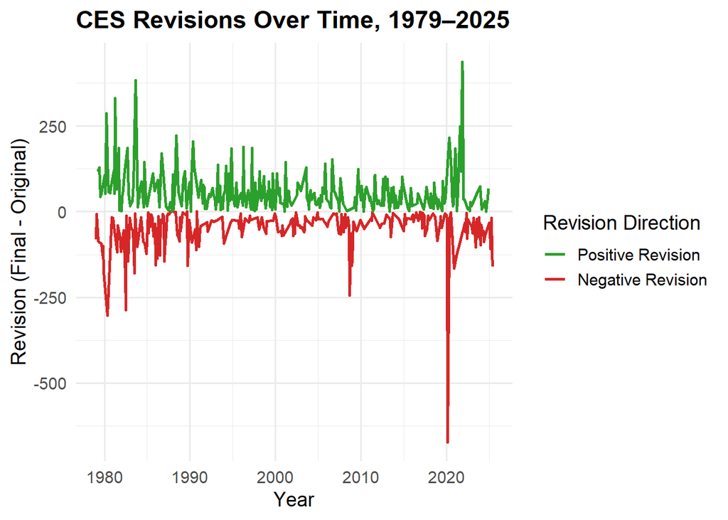

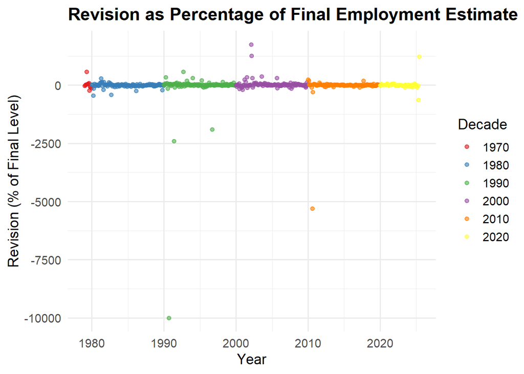

```
[1] 11.25899
```

```
[1] 83.36729
```

```
    One Sample t-test

data:  ces_test_tbl$revision_val
t = 3.1845, df = 555, p-value = 0.001531
alternative hypothesis: true mean is not equal to 0
95 percent confidence interval:
  4.314276 18.203709
sample estimates:
mean of x
 11.25899
```

```
# A tibble: 2 × 4
  period_group n_months neg_count neg_fraction
  <chr>           <int>     <int>        <dbl>
1 post_2000         304       135        0.444
2 pre_2000          252       102        0.405
```

```
    2-sample test for equality of proportions with continuity correction

data:  c(neg_pre, neg_post) out of c(n_pre, n_post)
X-squared = 0.71756, df = 1, p-value = 0.3969
alternative hypothesis: two.sided
95 percent confidence interval:
 -0.12536121  0.04672713
sample estimates:
   prop 1    prop 2
0.4047619 0.4440789
```

Task 5 — Discussion and Interpretation

The estimates obtained from the combined CES dataset show that monthly revisions are systematic rather than random statistical noise. The average revision value across 558 months is 11.26 thousand jobs, which is both economically meaningful and highly statistically significant. The one-sample t-test rejects the null hypothesis that the true mean revision is zero, with a t-statistic of approximately 3.19 and a p-value well below the conventional 5 percent level. This indicates that the first release of payroll employment data typically understates the final value reported by BLS. In other words, revisions on average tend to be positive, although individual months may still show negative adjustments.

When separating the data into months prior to 2000 and months after 2000, the share of negative revisions appears relatively stable rather than structurally changing. Before 2000, roughly 40.5% of months exhibited downward revisions, compared to 44.4% after 2000. A proportions test confirms that this difference is not statistically significant, with a p-value near 0.397, implying we cannot reject the null hypothesis of equal proportions. Even though BLS methodology, payroll survey coverage and benchmarking have evolved over time, the frequency of downward adjustments has not substantially shifted. From a policy or forecasting standpoint, this suggests that revisions are persistent features of CES data rather than artifacts of a particular decade.

Just as importantly, the persistent positivity of average revisions implies a potentially systematic bias in the preliminary CES release. Since the advance estimate tends to understate final employment in the aggregate, real-time analysts and Federal Reserve watchers should be cautious about interpreting a single monthly report. Incorporating historical revision behavior when forecasting or conducting sentiment analysis may lead to better real-time assessment of labor market conditions.

Extra Credit Analysis — Do large job swings predict bigger revisions?

From a real-time policy perspective, this suggests analysts should treat large preliminary CES changes with a higher degree of skepticism, since they are more likely to be modified appreciably in subsequent releases. Automating an adjustment for historical revision patterns could improve short-term forecasting in macroeconomic models and improve communication about uncertainty in monthly employment releases.